# Homework 15

2024-04-15

# 1. The probability of completing a difficult PhD program is 0.7. Calculate the probability that in a cohort of 29 students, 3 or fewer students do not complete the degree.

mathematical solution:

(29 3)(.3)^3 (.7)^26 = P(exactly 3 DNF)

repeat for

2: 1: 0:

```r
pbinom(3, 29, .3)
```

```
## [1] 0.01209502
```

# 2. Let X be the number of students who complete a difficult PhD program in a cohort of 29 students. Generate a plot of the probability mass function and cumulative probability function for X. Let p = .7 , as in the previous problem.

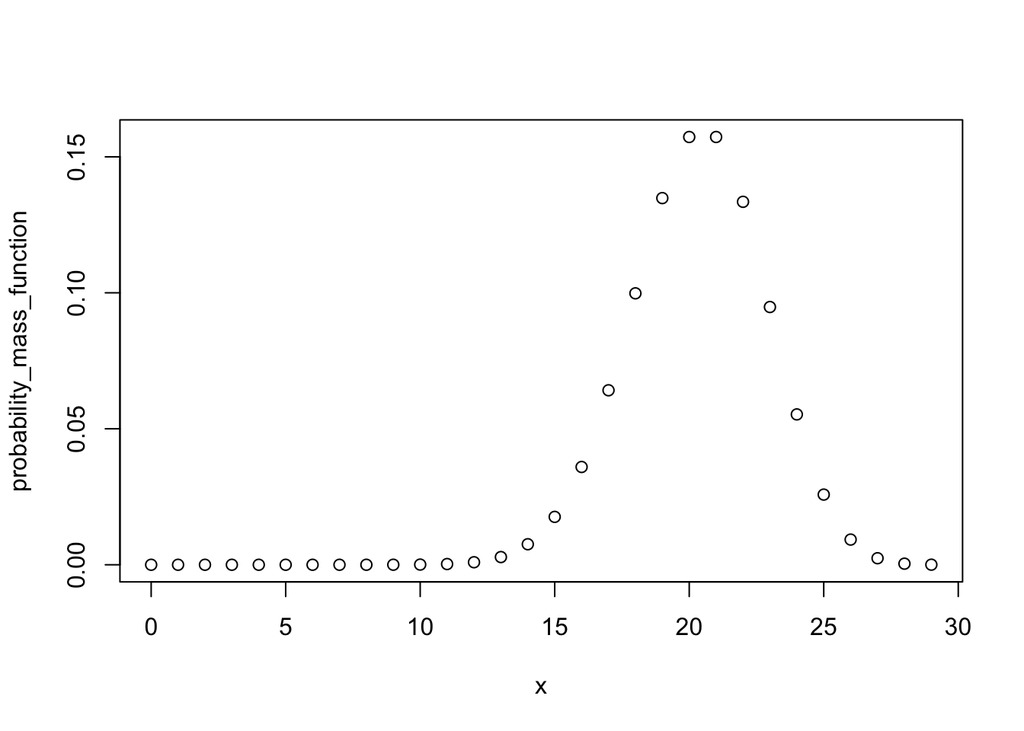

```r
# Probability Mass Function:
x <- seq(0, 29, 1)
probability_mass_function <- dbinom(x, 29, .7)

plot(x, probability_mass_function)
```

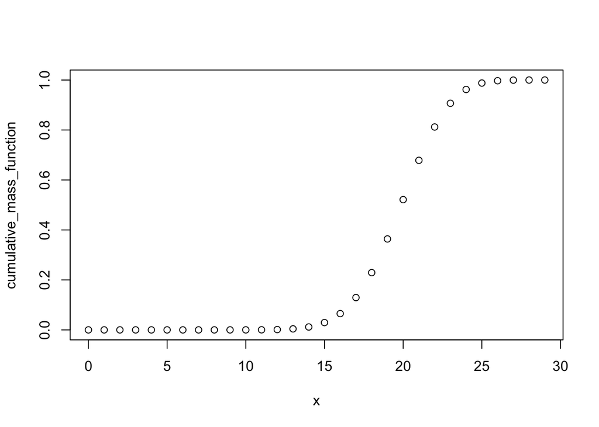

```r
# Cumulative Mass Function:
x <- seq(0, 29, 1)
cumulative_mass_function <- pbinom(x, 29, .7)

plot(x, cumulative_mass_function)
```

# 3. Suppose was unknown and needed to be estimated from data. Suppose 22 completed in a cohort of 29.

# 4. Estimate p with Maximum Likelihood. Generate a 1/20 support interval.

calculate an interval that determines uncertianty

support interval : choose a value of k why determining where graph interesections interval on the left and right

1/20 support interval where k = 0.05:

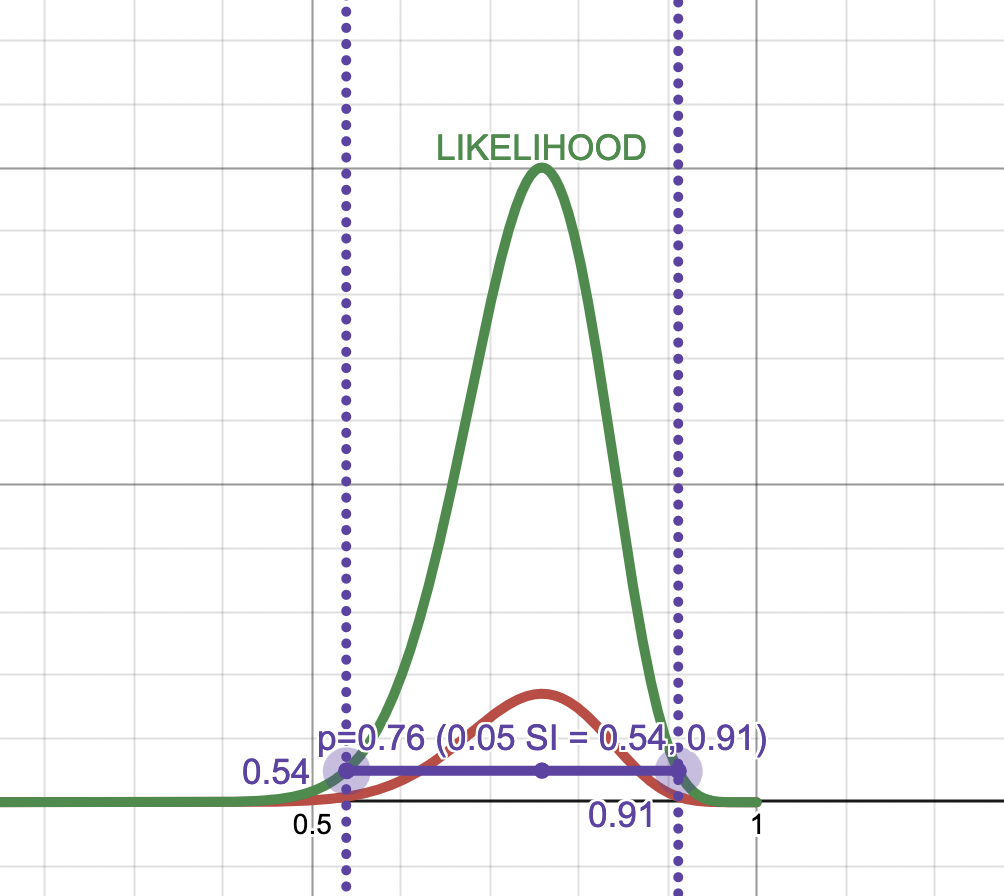

screenshot from desmos

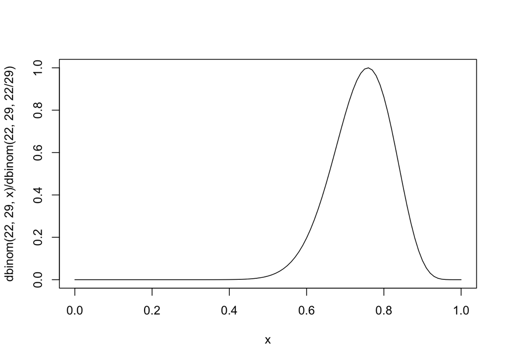

```r
# in this case, x is known and p is unknown
# mathematical: likley hood function for binomial random variable: L(p) = dbinom(x=22, N=29), p) domain for p is (0:1)
# normalize likleyhood for max is always greater than 1: L(p) = dbinom(x=22, N=29), p)/C
# calculate an interval that determines uncertianty

curve(dbinom(22, 29, x)/dbinom(22,29, 22/29), 0, 1)
```

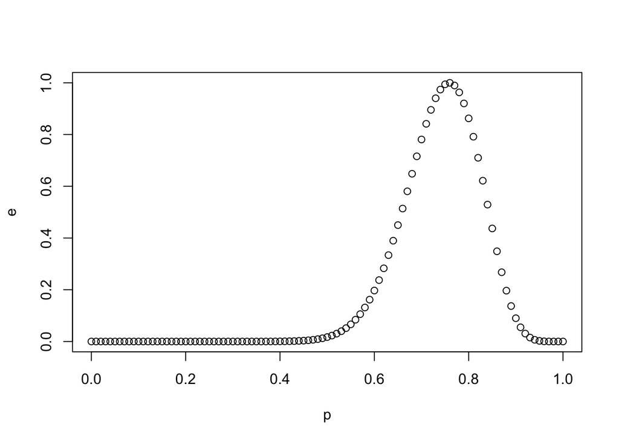

```r
# another method:

p <- seq(0,1,by=0.01)
e <- dbinom(22, 29, p)/dbinom(22, 29, 22/29)

plot(p,e)
```

# 5. Esimate p was a Bayesian Posterior. Generate a 0.95 credible interval.

We must identify prior beliefs to generate posterior - change d until 95% of interval is inside posterior.

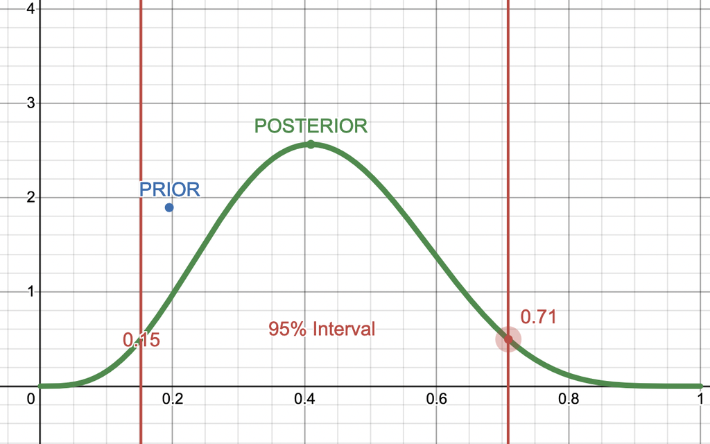

screenshot from desmos

# 6. In this difficult program, students complete the degree after 5 years (no variation). A professor decides to stop taking new students after advising 10 students to completion. She also decides to retire after all of her active students graduate. If the professor only takes 1 student a year (at the start of the program), what is the probability that the professor will be retired in 20 years?

- find point where cumsum = 10 (10 students sucessfully complete)
- negative binomial where we have a predetermined number of successes and want to know the humber of trials
- will the cumulative sum be 10 before year 15?

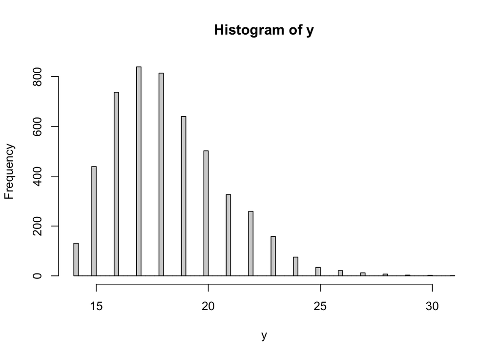

```r
# Simulation:

y <- replicate(5000, {
x <- rbinom(100, 1 , 0.7)
which(cumsum(x) == 10)[1] + 4
})
# visualize distribution
hist(y, breaks=100)
```

```r
table(y) |> proportions()
```

```
## y
##     14     15     16     17     18     19     20     21     22     23     24
## 0.0262 0.0878 0.1474 0.1678 0.1628 0.1280 0.1004 0.0652 0.0518 0.0316 0.0150
##     25     26     27     28     29     30     31
## 0.0068 0.0042 0.0024 0.0014 0.0006 0.0004 0.0002
```

```r
# add up all the times they retire before 20 years and average:
mean(y<=20)
```

```
## [1] 0.8204
```

```r
# negative binom: use number of failures by kth success
# (number of times, stopping rule, probability of success)
rnbinom(20000, 10, 0.7)
```

[output not shown]

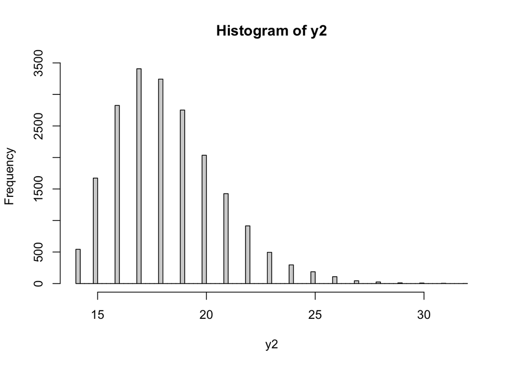

```r
# total number of students is z+ 10 and will graduate in 4 years: below gives year of retirment
y2 <- rnbinom(20000, 10, 0.7) + 10 + 4
hist(y2, breaks=100)
```

```r
# mathamatical:
# P(x<= 20) = p(z+10+4 <= 20) = P(z<=6)
# use pnbinom to get cumulative left hand probability:
pnbinom(6, 10, 0.7)
```

```
## [1] 0.8246866
```

# 7. 3 prizes are awarded to the first 3 correct solutions of a difficult problem. Suppose the probability of a correct solution is 0.1. What is the probability that all three prizes will be awarded by the 25th submission?

```r
# P(3rd price <= 25) = P(F+3 <= 25) = P(F <= 22)
pnbinom(22, 3, .1)
```

```
## [1] 0.4629059
```